# 复共线性与岭回归

`longley`是展示复共线性的经典数据。这里不先计算相关系数或VIF，而是先像普通回归一样拟合模型，从结果本身发现问题。

## 先拟合普通最小二乘模型

以就业人数`Employed`为响应变量，其余6个变量全部进入模型。对原始数据做标准化后再拟合模型。

```r
longley_data <- datasets::longley
longley_predictors <- c(
  "GNP.deflator",
  "GNP",
  "Unemployed",
  "Armed.Forces",
  "Population",
  "Year"
)
longley_standardized_predictors <- as.data.frame(
  scale(longley_data[longley_predictors])
)
longley_data <- cbind(
  Employed = longley_data$Employed,
  longley_standardized_predictors
)
longley_ols <- lm(Employed ~ ., data = longley_data)
summary(longley_ols)
```

```
Call:
lm(formula = Employed ~ ., data = longley_data)

Residuals:
     Min       1Q   Median       3Q      Max
-0.41011 -0.15767 -0.02816  0.10155  0.45539

Coefficients:
             Estimate Std. Error t value Pr(>|t|)
(Intercept)  65.31700    0.07621 857.026  < 2e-16 ***
GNP.deflator  0.16254    0.91636   0.177 0.863141
GNP          -3.56025    3.32884  -1.070 0.312681
Unemployed   -1.88783    0.45639  -4.136 0.002535 **
Armed.Forces -0.71904    0.14912  -4.822 0.000944 ***
Population   -0.35549    1.57259  -0.226 0.826212
Year          8.70850    2.16851   4.016 0.003037 **
---
Signif. codes:  0 '***' 0.001 '**' 0.01 '*' 0.05 '.' 0.1 ' ' 1

Residual standard error: 0.3049 on 9 degrees of freedom
Multiple R-squared:  0.9955,    Adjusted R-squared:  0.9925
F-statistic: 330.3 on 6 and 9 DF,  p-value: 4.984e-10
```

这个输出出现了值得追问的现象：系数表显示若干估计的标准误相对于系数本身很大。

“整体显著且$R^2$很高，单个系数却不稳定”是复共线性的典型信号。多个自变量可能共同解释了就业人数，却很难把这部分解释力稳定地分配给某一个系数。此时有必要返回自变量本身，检查它们是否包含大量重复信息。

## 相关性热图与VIF

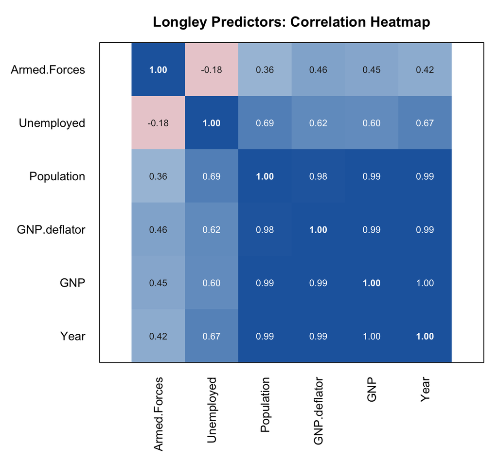

```r
longley_x <- longley_data[
  setdiff(names(longley_data), "Employed")
]
colour_main <- "#355c8a"
colour_smooth <- "#c45a3c"

plot_correlation_heatmap <- function(correlation, title) {
  distance <- as.dist(1 - abs(correlation))
  variable_order <- hclust(distance)$order
  ordered_correlation <- correlation[
    variable_order,
    variable_order,
    drop = FALSE
  ]
  displayed_correlation <- ordered_correlation[
    nrow(ordered_correlation):1,
    ,
    drop = FALSE
  ]
  palette <- colorRampPalette(
    c("#b2182b", "#f7f7f7", "#2166ac")
  )(201)

  old_par <- par(mar = c(7, 7, 3, 1))
  image(
    x = seq_len(ncol(displayed_correlation)),
    y = seq_len(nrow(displayed_correlation)),
    z = t(displayed_correlation),
    col = palette,
    zlim = c(-1, 1),
    axes = FALSE,
    xlab = "",
    ylab = "",
    main = title,
    asp = 1
  )
  axis(
    1,
    at = seq_len(ncol(displayed_correlation)),
    labels = colnames(displayed_correlation),
    las = 2,
    tick = FALSE
  )
  axis(
    2,
    at = seq_len(nrow(displayed_correlation)),
    labels = rownames(displayed_correlation),
    las = 2,
    tick = FALSE
  )

  for (row in seq_len(nrow(displayed_correlation))) {
    for (column in seq_len(ncol(displayed_correlation))) {
      value <- displayed_correlation[row, column]
      text(
        column,
        row,
        labels = sprintf("%.2f", value),
        col = ifelse(abs(value) >= 0.55, "white", "grey15"),
        cex = 0.78,
        font = ifelse(row + column == nrow(displayed_correlation) + 1, 2, 1)
      )
    }
  }

  box()
  par(old_par)
}

longley_correlation <- cor(longley_x)

plot_correlation_heatmap(
  longley_correlation,
  "Longley Predictors: Correlation Heatmap"
)
```

从图中可以发现`Year`、`GNP`、`Population`和`GNP.deflator`之间存在强相关关系。再计算VIF值与条件数：

```r
longley_x_matrix <- as.matrix(longley_x)
calculate_vif <- function(x) {
  result <- vapply(
    seq_len(ncol(x)),
    function(j) {
      auxiliary_model <- lm(x[, j] ~ x[, -j, drop = FALSE])
      1 / (1 - summary(auxiliary_model)$r.squared)
    },
    numeric(1)
  )

  names(result) <- colnames(x)
  result
}

longley_vif <- calculate_vif(longley_x_matrix)
longley_eigenvalues <- eigen(
  longley_correlation,
  symmetric = TRUE,
  only.values = TRUE
)$values
longley_condition_indices <- max(longley_eigenvalues) / min(longley_eigenvalues)

sort(longley_vif, decreasing = TRUE)
```

```
         GNP         Year   Population GNP.deflator   Unemployed Armed.Forces
  1788.51348    758.98060    399.15102    135.53244     33.61889      3.58893
```

```r
longley_condition_indices
```

```
[1] 12220.01
```

由输出可见，多个VIF远大于常用警示值，条件数也很高。这解释了前面系数标准误较大、显著性结论不稳定的原因。删除变量并不是唯一选择：若变量具有明确含义而分析目标主要是预测，可以保留它们并使用岭回归。

## 岭回归

下面使用`MASS::lm.ridge`计算岭迹。

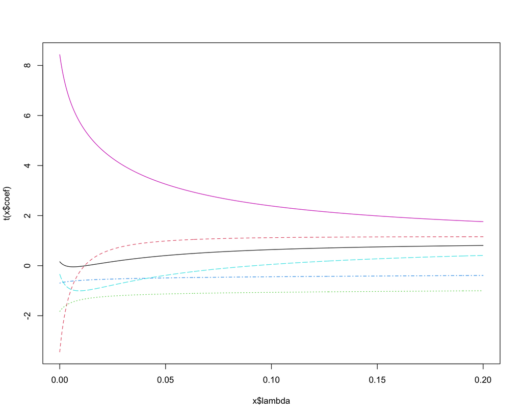

```r
if (!requireNamespace("MASS", quietly = TRUE)) {
  stop("This document requires the MASS package.")
}

lambda_grid <- seq(0, 0.2, by = 0.0005)
longley_ridge_path <- MASS::lm.ridge(
  Employed ~ .,
  data = longley_data,
  lambda = lambda_grid
)

plot(longley_ridge_path)
```

岭迹展示了系数随$\lambda$增加逐渐收缩并趋于稳定的过程。从岭际图上看，我们可以选择0.1作为惩罚强度。